# SVEMnet Vignette

Andrew T. Karl

October 13, 2025

# Version

version 2.3.1

# Summary

`SVEMnet` implements Self-Validated Ensemble Models (SVEM, Lemkus et al. 2021) and the SVEM whole model test (Karl 2024) using Elastic Net regression via the `glmnet` package Friedman et al. (2010). This vignette provides an overview of the package’s functionality and usage.

# Preface - Note from the author

The motivation to create the `SVEMnet` package was primarily to have a personal sandbox to explore SVEM performance in different scenarios and with various modifications to its structure. As noted in the documentation, I used `GPT o1-preview` to help form the code structure of the package and to code the Roxygen structure of the documentation. I have subsequently used more recent versions for auditing. The SVEM significance test R code comes from the supplementary material of Karl (2024). I wrote that code by hand and validated each step (not including the creation of the SVEM predictions) against corresponding results in JMP (the supplementary material of Karl (2024) provides the matching JSL script). For the `SVEMnet()` code, assuming only a single value of alpha for `glmnet` is being tested, the heart of the SVEM code is simply

```r
#partial code for illustration of the SVEM loop
coef_matrix <- matrix(NA, nrow = nBoot, ncol = p + 1)
 for (i in 1:nBoot) {
      U <- runif(n)
      w_train <- -log(U)
      w_valid <- -log(1 - U)
      #match glmnet normalization of training weight vector
      w_train <- w_train * (n / sum(w_train))
      w_valid <- w_valid * (n / sum(w_valid))
      glmnet(
          X, y_numeric,
          alpha = alpha,
          weights = w_train,
          intercept = TRUE,
          standardize = standardize,
          maxit = 1e6,
          nlambda = 500
      )
      predict(fit, newx = X)
      val_errors <- colSums(w_valid * (y_numeric - pred_valid)^2)
      k_values <- fit$df
      n_obs <- length(y_numeric)
      aic_values <- n_obs * log(val_errors / n_obs) + 2 * k_values
         # Choose lambda
      if (objective == "wSSE") {
        idx_min <- which.min(val_errors)
        lambda_opt <- fit$lambda[idx_min]
        val_error <- val_errors[idx_min]
      } else if (objective == "wAIC") {
        idx_min <- which.min(aic_values)
        lambda_opt <- fit$lambda[idx_min]
        val_error <- aic_values[idx_min]
      }
      coef_matrix[i, ] <- as.vector(coef(fit, s = lambda_opt))
}
```

However, to get this to a stable implementation that includes error and warning handling and structure to pass to S3 methods for `predict()`, `coef()`, `plot()`, etc, it was only practical for me to utilize help from GPT o1-preview. I simply would not have taken the time to add that structure otherwise, and my implementation would have been inferior. I reviewed any of the code that was generated from this tool before integrating it, and corrected its occasional mistakes. If someone would like to create a purely human-written set of code for a similar purpose, let me know and I will be happy to add links to your package and a description to the `SVEMnet` documentation.

Later revisions make use of later versions of GPT for code auditing, stress testing, and simulaiton. Many of the later entries in this vignette were written with GPT (code, analysis, summary).

# SVEMnet Example 1

```r
library(SVEMnet)

# Example data
data <- iris
svem_model <- SVEMnet(Sepal.Length ~ ., data = data, relaxed=FALSE,glmnet_alpha=c(1),nBoot = 50)
coef(svem_model)
```

```
##                   Percent of Bootstraps Nonzero
## Sepal.Width                                 100
## Petal.Length                                100
## Petal.Width                                  94
## Speciesvirginica                             92
## Speciesversicolor                            88
```

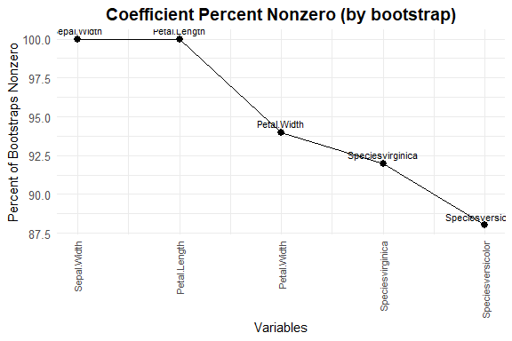

Generate a plot of actual versus predicted values:

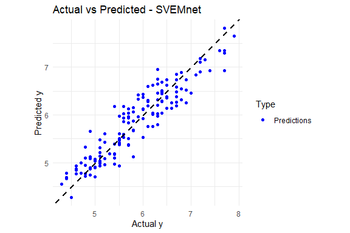

```r
plot(svem_model)
```

Predict outcomes for new data using the `predict()` function:

```r
predictions <- predict(svem_model, data)
print(predictions)
```

```
##   [1] 5.010590 4.745862 4.778765 4.871797 5.063536 5.385213 4.929582 5.030634
##   [9] 4.692916 4.899860 5.189471 5.103622 4.773925 4.554959 5.129341 5.503964
##  [17] 5.093258 4.982527 5.360331 5.214353 5.176611 5.133344 4.771581 5.039476
##  [25] 5.322589 4.891840 5.047496 5.083579 4.957645 4.997731 4.944785 4.974507
##  [33] 5.429317 5.381210 4.871797 4.705776 4.937602 5.091599 4.672873 5.030634
##  [41] 4.909538 4.274190 4.778765 5.044315 5.478245 4.717799 5.315405 4.851753
##  [49] 5.189471 4.904699 6.459132 6.285092 6.524101 5.499763 6.146298 6.129435
##  [57] 6.455952 5.125977 6.255370 5.610494 5.060172 5.960234 5.531007 6.300295
##  [65] 5.525482 6.187220 6.179200 5.868724 5.755635 5.588792 6.419868 5.764491
##  [73] 6.206427 6.303476 6.036403 6.134275 6.320338 6.488018 6.126254 5.377846
##  [81] 5.462858 5.417932 5.666620 6.430233 6.179200 6.362920 6.378123 5.791718
##  [89] 5.943372 5.605654 5.978618 6.280252 5.686663 5.073031 5.857523 6.044424
##  [97] 5.963415 6.036403 4.931893 5.837480 6.954904 6.148710 6.835331 6.647608
## [105] 6.734279 7.346252 5.661012 7.158530 6.581803 7.186729 6.385375 6.294687
## [113] 6.543376 5.941766 6.061339 6.447163 6.627565 7.814743 7.297309 5.923246
## [121] 6.739118 6.027615 7.341413 6.030796 6.848190 7.098401 6.010752 6.189633
## [129] 6.510473 6.902658 6.931543 7.651903 6.482410 6.313909 6.601024 6.925182
## [137] 6.743957 6.680511 6.116644 6.523332 6.585120 6.248240 6.148710 6.885096
## [145] 6.735937 6.268283 5.969830 6.352472 6.626043 6.335610
```

## Whole Model Significance Testing

This is the serial version of the significance test. It is slower but the code is less complicated to read than the faster parallel version.

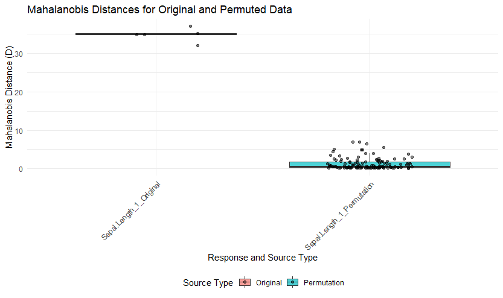

Whole model test result

```r
test_result <- svem_significance_test(Sepal.Length ~ ., data = data)
print(test_result)
plot(test_result)
SVEM Significance Test p-value:
[1] 0
```

Note that there is a parallelized version that runs much faster

```r
test_result <- svem_significance_test_parallel(Sepal.Length ~ ., data = data)
print(test_result)
plot(test_result)
SVEM Significance Test p-value:
[1] 0
```

# SVEMnet Example 2

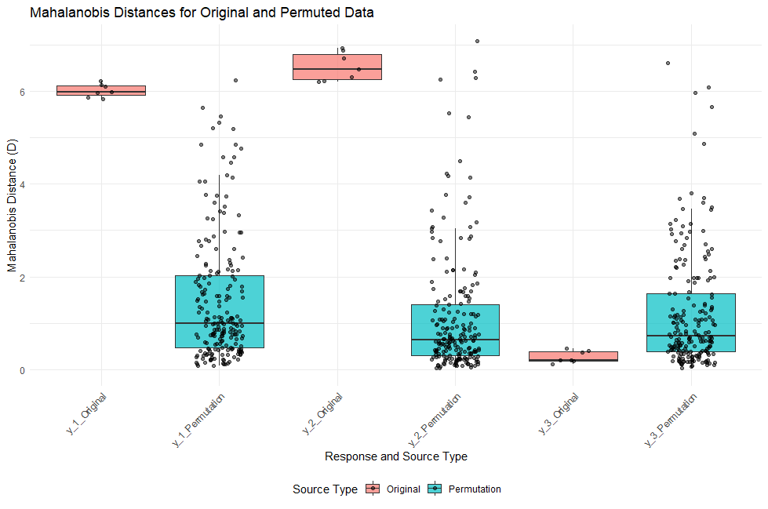

Whole Model Test Results for Example 2

```r
# Simulate data
set.seed(1)
n <- 25
X1 <- runif(n)
X2 <- runif(n)
X3 <- runif(n)
X4 <- runif(n)
X5 <- runif(n)

#y only depends on X1 and X2
y <- 1 + X1 +  X2 + X1 * X2 + X1^2 + rnorm(n)
data <- data.frame(y, X1, X2, X3, X4, X5)

# Perform the SVEM significance test
test_result <- svem_significance_test_parallel(
  y ~ (X1 + X2 + X3)^2 + I(X1^2) + I(X2^2) + I(X3^2),
  data = data

)

# View the p-value
print(test_result)
SVEM Significance Test p-value:
[1] 0.009399093


test_result2 <- svem_significance_test_parallel(
  y ~ (X1 + X2 )^2 + I(X1^2) + I(X2^2),
  data = data
)

# View the p-value
print(test_result2)
SVEM Significance Test p-value:
[1] 0.006475736

#note that the response does not depend on X4 or X5
test_result3 <- svem_significance_test_parallel(
  y ~ (X4 + X5)^2 + I(X4^2) + I(X5^2),
  data = data
)

# View the p-value
print(test_result3)
SVEM Significance Test p-value:
[1] 0.8968502

# Plot the Mahalanobis distances
plot(test_result,test_result2,test_result3)
```

# 21DEC2024: Add glmnet.cv wrapper

Newly added wrapper for cv.glmnet() to compare performance of SVEM to glmnet’s native CV implementation.

# 08SEP2025: Added relaxed option

Simulations show improved behavior from a relaxed grid search that allows the model to apply a lighter penalty to parameteres retained from the initial elastic net fit. This option tends to hurt RMSE on holdout data for cross validated glmnet, but the SVEM bootstraps average over the addtional variability introduced by this option and produce smaller RMSE on holdout data.

# 25SEP2025

## 1. Introduction

SVEMnet implements Self-Validated Ensemble Models (SVEM) using elastic-net (lasso/ridge) base learners via `glmnet`. SVEM averages predictions from bootstrap-resampled fits chosen by an internal validation scheme, and exposes helpers for (i) deterministic factor-space expansion, (ii) whole-model significance testing, and (iii) multi-response random-search optimization with optional **mixture** constraints.

This vignette walks through a minimal workflow and ends with an end-to-end lipid formulation example across three responses with a mixture constraint and an optimization step.

## 2. A small example

```r
# Simulate simple mixed-type data
set.seed(1)
n  <- 120
X1 <- runif(n)
X2 <- runif(n)
F  <- factor(sample(c("lo","hi"), n, replace = TRUE))
y1 <- 1 + 1.5*X1 - 0.8*X2 + 0.4*(F=="hi") + rnorm(n, 0, 0.2)
y2 <- 0.7 + 0.4*X1 + 0.4*X2 - 0.2*(F=="hi") + rnorm(n, 0, 0.2)
dat <- data.frame(y1, y2, X1, X2, F)

# Fit two SVEM models (keep defaults modest in vignettes)
m1 <- SVEMnet(y1 ~ X1 + X2 + F, dat, nBoot = 30)
m2 <- SVEMnet(y2 ~ X1 + X2 + F, dat, nBoot = 30)

# Predict
head(predict(m1, newdata = dat))
head(predict(m2, newdata = dat))
```

## 3. Whole-model significance tests (serial)

The serial significance test draws many evaluation points in the factor space, refits SVEM repeatedly on original and permuted responses, and compares distance distributions via a parametric reference fit.

```r
res_serial_y1 <- svem_significance_test(
  y1 ~ X1 + X2 + F, dat,
  nPoint = 2000, nSVEM = 10, nPerm = 150,
  nBoot = 80, glmnet_alpha = 1, relaxed = FALSE,
  verbose = TRUE
)
res_serial_y1$p_value
```

## 4. Random-search optimization with diverse candidates

Use `svem_optimize_random()` to define goals per response and pick a best recipe plus `k_candidates` diverse high scorers (PAM *medoids*; real sampled rows).

```r
objs  <- list(y1 = m1, y2 = m2)
goals <- list(
  y1 = list(goal = "max",    weight = 0.6),
  y2 = list(goal = "target", weight = 0.4, target = 0.9)
)

opt_out <- svem_optimize_random(
  objects      = objs,
  goals        = goals,
  n            = 3000,
  agg          = "mean",
  debias       = FALSE,
  ci           = TRUE,
  level        = 0.95,
  k_candidates = 5,
  top_frac     = 0.02,
  verbose      = TRUE
)

opt_out$best_x
opt_out$best_pred
head(opt_out$candidates)
```

## 5. End-to-end lipid formulation example

In this section we use the bundled `lipid_screen` dataset and demonstrate the complete flow over three responses (`Potency`, `Size`, `PDI`) with a **mixture** constraint on composition.

**Key columns**

- Composition fractions in **proportion** units: `PEG`, `Helper`, `Ionizable`, `Cholesterol`
- Categorical: `Ionizable_Lipid_Type`
- Numeric process: `N_P_ratio`, `flow_rate`
- Responses: `Potency`, `Size`, `PDI`

**Mixture constraints**

- The four composition variables must sum to 1
- Bounds: `PEG ∈ [0.01, 0.05]`, and `Helper`, `Ionizable`, `Cholesterol ∈ [0.10, 0.60]`

### 5.1 Build and lock a shared expansion

We create a deterministic expansion with `bigexp_terms()` (up to 3-way interactions here) and reuse it for each response via `bigexp_formula()`.

```r
data(lipid_screen)
str(lipid_screen)

spec <- bigexp_terms(
  Potency ~ PEG + Helper + Ionizable + Cholesterol +
    Ionizable_Lipid_Type + N_P_ratio + flow_rate,
  data               = lipid_screen,
  factorial_order    = 3,
  include_pure_cubic = TRUE,
  include_pc_3way    = FALSE
)

form_pot <- bigexp_formula(spec, "Potency")
form_siz <- bigexp_formula(spec, "Size")
form_pdi <- bigexp_formula(spec, "PDI")
```

### 5.2 Fit the three SVEM models

Keep `debias = FALSE` in examples per our package convention.

```r
set.seed(1)
fit_pot <- SVEMnet(form_pot, lipid_screen, nBoot = 40)
fit_siz <- SVEMnet(form_siz, lipid_screen, nBoot = 40)
fit_pdi <- SVEMnet(form_pdi, lipid_screen, nBoot = 40)

objs <- list(Potency = fit_pot, Size = fit_siz, PDI = fit_pdi)
```

### 5.3 Whole-model significance tests

#### 5.3.1 Serial per response

```r
test_pot <- svem_significance_test(form_pot, lipid_screen, nPoint=2000, nSVEM=10, nPerm=150,
                                   nBoot=80, glmnet_alpha=1, relaxed=FALSE, verbose=TRUE)
test_siz <- svem_significance_test(form_siz, lipid_screen, nPoint=2000, nSVEM=10, nPerm=150,
                                   nBoot=80, glmnet_alpha=1, relaxed=FALSE, verbose=TRUE)
test_pdi <- svem_significance_test(form_pdi, lipid_screen, nPoint=2000, nSVEM=10, nPerm=150,
                                   nBoot=80, glmnet_alpha=1, relaxed=FALSE, verbose=TRUE)

c(Potency = test_pot$p_value, Size = test_siz$p_value, PDI = test_pdi$p_value)
```

#### 5.3.2 Parallel per response (run separately, then plot together)

> `svem_significance_test_parallel()` operates on **one** response at a time. Use it separately for each response and then combine the visuals with `plot.svem_significance_test()` by passing multiple results.

```r
# Parallel runs (example; adjust nCore to your machine)
par_pot <- svem_significance_test_parallel(form_pot, lipid_screen,
                                           nPoint=3000, nSVEM=10, nPerm=150,
                                           nCore = max(1L, parallel::detectCores()-1L),
                                           seed = 123, verbose=TRUE)
par_siz <- svem_significance_test_parallel(form_siz, lipid_screen,
                                           nPoint=3000, nSVEM=10, nPerm=150,
                                           nCore = max(1L, parallel::detectCores()-1L),
                                           seed = 123, verbose=TRUE)
par_pdi <- svem_significance_test_parallel(form_pdi, lipid_screen,
                                           nPoint=3000, nSVEM=10, nPerm=150,
                                           nCore = max(1L, parallel::detectCores()-1L),
                                           seed = 123, verbose=TRUE)

# Plot all three together
plot(par_pot, par_siz, par_pdi, labels = c("Potency","Size","PDI"))
```

### 5.4 Random-search optimization with mixture constraints

We construct the mixture constraint and optimize a weighted multi-response goal, returning the best design and 5 diverse high-score **existing** rows (PAM medoids).

```r
goals <- list(
  Potency = list(goal = "max", weight = 0.7),
  Size    = list(goal = "min", weight = 0.2),
  PDI     = list(goal = "min", weight = 0.1)
)

mixL <- list(list(
  vars  = c("Cholesterol","PEG","Ionizable","Helper"),
  lower = c(0.10, 0.01, 0.10, 0.10),
  upper = c(0.60, 0.05, 0.60, 0.60),
  total = 1
))

opt_out <- svem_optimize_random(
  objects        = objs,
  goals          = goals,
  n              = 10000,
  mixture_groups = mixL,
  agg            = "mean",
  debias         = FALSE,
  ci             = TRUE,
  level          = 0.95,
  k_candidates   = 5,
  top_frac       = 0.01,
  verbose        = TRUE
)

opt_out$best_x
opt_out$best_pred
opt_out$best_ci
opt_out$candidates
```

# References and Citations

1. **Lemkus, T., Gotwalt, C., Ramsey, P., & Weese, M. L. (2021).** *Self-Validated Ensemble Models for Elastic Net Regression*.  
   *Chemometrics and Intelligent Laboratory Systems*, 219, 104439.  
   DOI: 10.1016/j.chemolab.2021.104439
2. **Karl, A. T. (2024).** *A Randomized Permutation Whole-Model Test for SVEM*.  
   *Chemometrics and Intelligent Laboratory Systems*, 249, 105122.  
   DOI: 10.1016/j.chemolab.2024.105122
3. **Friedman, J. H., Hastie, T., & Tibshirani, R. (2010).** *Regularization Paths for Generalized Linear Models via Coordinate Descent*.  
   *Journal of Statistical Software*, 33(1), 1–22.  
   DOI: 10.18637/jss.v033.i01
4. **Gotwalt, C., & Ramsey, P. (2018).** *Model Validation Strategies for Designed Experiments Using Bootstrapping Techniques With Applications to Biopharmaceuticals*.  
   *JMP Discovery Conference*.  
   [Link](https://community.jmp.com/t5/Abstracts/Model-Validation-Strategies-for-Designed-Experiments-Using/ev-p/849873/redirect_from_archived_page/true)
5. **Ramsey, P., Gaudard, M., & Levin, W. (2021).** *Accelerating Innovation with Space-Filling Mixture Designs, Neural Networks, and SVEM*.  
   *JMP Discovery Conference*.  
   [Link](https://community.jmp.com/t5/Abstracts/Accelerating-Innovation-with-Space-Filling-Mixture-Designs/ev-p/756841)
6. **Ramsey, P., & Gotwalt, C. (2018).** *Model Validation Strategies for Designed Experiments Using Bootstrapping Techniques With Applications to Biopharmaceuticals*.  
   *JMP Discovery Summit Europe*.  
   [Link](https://community.jmp.com/t5/Abstracts/Model-Validation-Strategies-for-Designed-Experiments-Using/ev-p/849647/redirect_from_archived_page/true)
7. **Ramsey, P., Levin, W., Lemkus, T., & Gotwalt, C. (2021).** *SVEM: A Paradigm Shift in Design and Analysis of Experiments*.  
   *JMP Discovery Summit Europe*.  
   [Link](https://community.jmp.com/t5/Abstracts/SVEM-A-Paradigm-Shift-in-Design-and-Analysis-of-Experiments-2021/ev-p/756634)
8. **Ramsey, P., & McNeill, P. (2023).** *CMC, SVEM, Neural Networks, DOE, and Complexity: It’s All About Prediction*.  
   *JMP Discovery Conference*.
9. **Karl, A., Wisnowski, J., & Rushing, H. (2022).** *JMP Pro 17 Remedies for Practical Struggles with Mixture Experiments*.  
   *JMP Discovery Conference*.  
   [Link](https://doi.org/10.13140/RG.2.2.34598.40003/1)
10. **Xu, L., Gotwalt, C., Hong, Y., King, C. B., & Meeker, W. Q. (2020).** *Applications of the Fractional-Random-Weight Bootstrap*.  
    *The American Statistician*, 74(4), 345–358.  
    [Link](https://doi.org/10.1080/00031305.2020.1731599)
11. **Karl, A. T. (2024).** *SVEMnet: Self-Validated Ensemble Models with Elastic Net Regression*.  
    R package
12. **JMP Help Documentation** *Overview of Self-Validated Ensemble Models*.  
    [Link](https://www.jmp.com/support/help/en/18.1/?utm_source=help&utm_medium=redirect#page/jmp/overview-of-selfvalidated-ensemble-models.shtml)